# Comparison of MoCA & MMSE Impairment Scores with Clinical Diagnoses

Load and prepare the NACC data for analysis, ensuring all necessary columns are included

```python
import pandas as pd
from tableone import TableOne

nacc_df = pd.read_csv("data/NACC_data.csv", index_col = "NACCID")
df_analysis = nacc_df[["NACCUDSD","NACCMOCA","NACCMMSE","NACCMOCA_est"]].copy()
df_analysis
```

| NACCID | NACCUDSD | NACCMOCA | NACCMMSE | NACCMOCA_est |
| --- | --- | --- | --- | --- |
| NACC020208 | MCI | 20.0 | NaN | NaN |
| NACC107305 | Normal cognition | 29.0 | NaN | NaN |
| NACC151065 | MCI | 17.0 | NaN | NaN |
| NACC187327 | Normal cognition | 27.0 | NaN | NaN |
| NACC188799 | MCI | 24.0 | NaN | NaN |
| ... | ... | ... | ... | ... |
| NACC993286 | Impaired-not-MCI | NaN | 30.0 | 28.0 |
| NACC994463 | Dementia | NaN | 26.0 | 20.0 |
| NACC995870 | Normal cognition | 28.0 | NaN | NaN |
| NACC998475 | MCI | NaN | 22.0 | 14.0 |
| NACC999391 | MCI | NaN | 28.0 | 23.0 |

44908 rows × 4 columns

Sample size

```python
participantNum = int(df_analysis.shape[0])

bothBatteries = df_analysis.dropna(subset=['NACCMOCA', 'NACCMMSE']).shape[0]

mocaOnlyNum = df_analysis['NACCMOCA'].count() - bothBatteries
mmseOnlyNum = df_analysis['NACCMMSE'].count() - bothBatteries

neitherBatteries = participantNum - (mocaOnlyNum + mmseOnlyNum + bothBatteries)

# Create a DataFrame
data = [
    ['MoCA Only', mocaOnlyNum],
    ['MMSE Only', mmseOnlyNum],
    ['Both', bothBatteries],
    ['Neither', neitherBatteries],
    ['Total', participantNum]
]

# Define the columns separately
columnsSampleTable = ['Assessment', 'Count']

# Create the table
sampleTableDF = pd.DataFrame(data, columns=columnsSampleTable)

# Display the table
sampleTableDF
```

|  | Assessment | Count |
| --- | --- | --- |
| 0 | MoCA Only | 11217 |
| 1 | MMSE Only | 31279 |
| 2 | Both | 1 |
| 3 | Neither | 2411 |
| 4 | Total | 44908 |

Categorize MoCA, MMSE, and derived MoCA scores as “Unimpaired” or “MCI” based on defined thresholds.

Defined thresholds:

```python
df_analysis.loc[:, 'Impairment_MoCA'] = df_analysis['NACCMOCA'].apply(
    lambda x: 'Unimpaired' if x >= 26 else ('MCI' if pd.notna(x) else x)
)


df_analysis.loc[:,'Impairment_MMSE'] = df_analysis['NACCMMSE'].apply(
    lambda x: 'Unimpaired' if x >= 21 else ('MCI' if pd.notna(x) else x)
)


df_analysis.loc[:, 'Impairment_Derived-MoCA'] = df_analysis['NACCMOCA_est'].apply(
    lambda x: 'Unimpaired' if x >= 26 else ('MCI' if pd.notna(x) else x)
)
```

Determine a unified survey recorded impairment (SRI) score for each row by using the MoCA score if available, otherwise using the MMSE score.

This process ensures that each row is assigned a single impairment classification.

```python
# Priority 1. MoCA 2. MMSE
def calculate_sri(row):
    if pd.notna(row['Impairment_MoCA']):
        return row['Impairment_MoCA']
    elif pd.notna(row['Impairment_MMSE']):
        return row['Impairment_MMSE']
    else:
        return pd.NA

df_analysis['SRI'] = df_analysis.apply(calculate_sri, axis=1)

# Placeholder just in case for the sri variable (sriScore = df_analysis['SRI'])


df_analysis[["Impairment_MoCA","Impairment_MMSE","SRI"]]
```

| NACCID | Impairment_MoCA | Impairment_MMSE | SRI |
| --- | --- | --- | --- |
| NACC020208 | MCI | NaN | MCI |
| NACC107305 | Unimpaired | NaN | Unimpaired |
| NACC151065 | MCI | NaN | MCI |
| NACC187327 | Unimpaired | NaN | Unimpaired |
| NACC188799 | MCI | NaN | MCI |
| ... | ... | ... | ... |
| NACC993286 | NaN | Unimpaired | Unimpaired |
| NACC994463 | NaN | Unimpaired | Unimpaired |
| NACC995870 | Unimpaired | NaN | Unimpaired |
| NACC998475 | NaN | Unimpaired | Unimpaired |
| NACC999391 | NaN | Unimpaired | Unimpaired |

44908 rows × 3 columns

# Saving this for dichotomous variables — table 1

```python
# Priority 1. MoCA 2. derived MoCA
def calculate_sri_with_rescores(row):
    if pd.notna(row['Impairment_MoCA']):
        return row['Impairment_MoCA']
    elif pd.notna(row['Impairment_Derived-MoCA']):
        return row['Impairment_Derived-MoCA']
    else:
        return pd.NA

sriScore = df_analysis.apply(calculate_sri_with_rescores, axis=1)
```

**Table #1 Results**

Prepare the data by filtering out certain clinical diagnoses and consolidating the remaining clinical diagnoses into simplified categories: Unimpaired, MCI, Unknown.

Then, compare these simplified clinical diagnoses with the survey recorded impairment to analyze the agreement between clinical diagnoses and survey results.

```python
# Filter the DataFrame to exclude rows where Clinical Diagnosis is 'Impaired-not-MCI'
filt = df_analysis['NACCUDSD'] != 'Impaired-not-MCI'
df_filtered = df_analysis.loc[filt].copy().reset_index(drop=True)



# Define a function to consolidate the remaining clinical diagnosis into two categories
def consolidate_diagnosis(diagnosis):
    if diagnosis == 'Normal cognition':
        return 'Unimpaired'
    elif diagnosis in ['MCI', 'Dementia']:
        return 'MCI'
    else:
        return 'Unknown'  # For any unexpected values





# Apply this function to create a new simplified clinical diagnosis column
df_filtered.loc[:,'Clinical_Diagnosis-Simplified'] = df_filtered['NACCUDSD'].apply(consolidate_diagnosis)


cross_tab = pd.crosstab(index=df_filtered['SRI'],
                        columns=df_filtered['Clinical_Diagnosis-Simplified'],
                        rownames=['Survey'],
                        colnames=['Clinical'])
cross_tab
```

| Clinical Survey | MCI | Unimpaired |
| --- | --- | --- |
| MCI | 10160 | 1744 |
| Unimpaired | 13370 | 15276 |

```python
# Make a copy of this variable for use for the optimal cutpoints
cutpointAnalysisMMSE = df_filtered.loc[:, ["Clinical_Diagnosis-Simplified", "NACCMMSE"]].copy()
cutpointAnalysisMOCA = df_filtered.loc[:, ["Clinical_Diagnosis-Simplified", "NACCMOCA"]].copy()

# Remove rows with NaN values
cutpointAnalysisMMSE = cutpointAnalysisMMSE.dropna()
cutpointAnalysisMOCA = cutpointAnalysisMOCA.dropna()
```

**Table #2 Results**

Calculate the new unified SRI score using NACCMOCA_est (MoCA score derived from MMSE) and NACCMOCA (MoCA score).

This process ensures that each row is assigned a single impairment classification.

```python
# Clean it up
df_filtered = df_filtered.loc[:, ["Impairment_MoCA", "Impairment_Derived-MoCA", "Clinical_Diagnosis-Simplified","NACCMOCA_est"]]

# Priority 1. MoCA 2. derived MoCA
def calculate_sri_with_rescores(row):
    if pd.notna(row['Impairment_MoCA']):
        return row['Impairment_MoCA']
    elif pd.notna(row['Impairment_Derived-MoCA']):
        return row['Impairment_Derived-MoCA']
    else:
        return pd.NA

df_filtered['new-SRI'] = df_filtered.apply(calculate_sri_with_rescores, axis=1)
df_filtered[['Impairment_MoCA','Impairment_Derived-MoCA','new-SRI']]
```

|  | Impairment_MoCA | Impairment_Derived-MoCA | new-SRI |
| --- | --- | --- | --- |
| 0 | MCI | NaN | MCI |
| 1 | Unimpaired | NaN | Unimpaired |
| 2 | MCI | NaN | MCI |
| 3 | Unimpaired | NaN | Unimpaired |
| 4 | MCI | NaN | MCI |
| ... | ... | ... | ... |
| 42910 | Unimpaired | NaN | Unimpaired |
| 42911 | NaN | MCI | MCI |
| 42912 | Unimpaired | NaN | Unimpaired |
| 42913 | NaN | MCI | MCI |
| 42914 | NaN | MCI | MCI |

42915 rows × 3 columns

Comparing “new-SRI” (newly-calculated SRI) with “Clinical_Diagnosis-Simplified” (patient’s corresponding clinical diagnosis).

```python
cross_tab = pd.crosstab(index=df_filtered['new-SRI'],
                        columns=df_filtered['Clinical_Diagnosis-Simplified'],
                        rownames=['Survey'],
                        colnames=['Clinical'])
cross_tab
```

| Clinical Survey | MCI | Unimpaired |
| --- | --- | --- |
| MCI | 20312 | 5120 |
| Unimpaired | 3218 | 11900 |

# Accuracy analysis

**Calculated accuracy for Table 2**: 79.44%

```python
nacc_df_clean = nacc_df.copy()

# Here we are using the calculated SRI score derived from the combination of the cognitive scores from MoCA and MMSE
nacc_df_clean["SRI"] = sriScore

# Create labels for the variables for better readability in the table
nacc_df_clean.rename(columns={
    'NACCAGE': 'Age',
    'SEX': 'Sex',
    'RACE': 'Race',
    'EDUC': 'Education (years)',
    'NACCBMI': 'BMI',
    'BPSYS': 'Systolic Blood Pressure',
    'BPDIAS': 'Diastolic Blood Pressure',
    'SRI': 'Cognitive Impairment',
}, inplace=True)



# Define the columns to be included in the TableOne
columns = ['Age', 'Sex', 'Race', 'Education (years)', 'BMI', 'Systolic Blood Pressure', 'Diastolic Blood Pressure']
categorical = ['Sex', 'Race']
groupby = 'Cognitive Impairment'

# Create the demographics table
table = TableOne(nacc_df_clean, columns=columns, categorical=categorical, groupby=groupby, pval=True)

# Print the table
table.tabulate(tablefmt="html")
```

|  |  | Missing | Overall | MCI | Unimpaired | P-Value |
| --- | --- | --- | --- | --- | --- | --- |
| n |  |  | 44908 | 26500 | 15997 |  |
| Age, mean (SD) |  | 0 | 71.5 (10.4) | 72.8 (10.1) | 69.3 (10.4) | <0.001 |
| Sex, n (%) | Female |  | 25647 (57.1) | 14171 (53.5) | 10147 (63.4) | <0.001 |
|  | Male |  | 19261 (42.9) | 12329 (46.5) | 5850 (36.6) |  |
| Race, n (%) | American Indian or Alaska Native |  | 395 (0.9) | 300 (1.1) | 86 (0.5) | <0.001 |
|  | Asian |  | 1191 (2.7) | 608 (2.3) | 337 (2.1) |  |
|  | Black or African American |  | 6302 (14.0) | 4291 (16.2) | 1794 (11.2) |  |
|  | Native Hawaiian or Other Pacific Islander |  | 47 (0.1) | 32 (0.1) | 11 (0.1) |  |
|  | None |  | 299 (0.7) | 211 (0.8) | 49 (0.3) |  |
|  | Other |  | 711 (1.6) | 566 (2.1) | 108 (0.7) |  |
|  | White |  | 35963 (80.1) | 20492 (77.3) | 13612 (85.1) |  |
| Education (years), mean (SD) |  | 356 | 15.1 (3.5) | 14.5 (3.6) | 16.2 (2.8) | <0.001 |
| BMI, mean (SD) |  | 5025 | 27.1 (5.3) | 27.1 (5.3) | 27.3 (5.4) | <0.001 |
| Systolic Blood Pressure, mean (SD) |  | 4176 | 134.2 (18.8) | 135.4 (19.2) | 132.3 (18.0) | <0.001 |
| Diastolic Blood Pressure, mean (SD) |  | 4188 | 75.4 (10.6) | 75.5 (10.7) | 75.3 (10.4) | 0.137 |

Determine the optimal cutpoint of MMSE scores using some built in packages; gold standard: clinical diagnosis

```python
import numpy as np
from sklearn.metrics import roc_curve, auc

# Assuming 'cutpointAnalysisMMSE' is your DataFrame with the necessary columns.
# Ensure the clinical diagnosis is binary coded
cutpointAnalysisMMSE['Clinical_Diagnosis_Binary'] = cutpointAnalysisMMSE['Clinical_Diagnosis-Simplified'].map({
    'Unimpaired': 0,
    'MCI': 1
})

# Invert MMSE scores so that lower scores become higher numbers and vice versa
cutpointAnalysisMMSE['Inverted_MMSE'] = 30 - cutpointAnalysisMMSE['NACCMMSE']

# Define true labels and scores (higher scores now indicate more impairment)
true_labels = cutpointAnalysisMMSE['Clinical_Diagnosis_Binary']
scores = cutpointAnalysisMMSE['Inverted_MMSE']

# Calculate the ROC curve
fpr, tpr, thresholds = roc_curve(true_labels, scores, pos_label=1)

# Calculate the AUC (Area Under the Curve)
roc_auc = auc(fpr, tpr)

# Find the optimal cutoff (where tpr is high and fpr is low, i.e., tpr - fpr is maximized)
optimal_idx = np.argmax(tpr - fpr)
optimal_threshold = 30 - thresholds[optimal_idx]  # Convert back to original MMSE scale

print("Area Under the ROC Curve (AUC):", roc_auc)
print("Optimal MMSE cutoff:", optimal_threshold)
```

```
Area Under the ROC Curve (AUC): 0.8781173476617559
Optimal MMSE cutoff: 27.0
```

**Calculated accuracy for New Cutoff for table**: 77.56%

Determine the optimal cutpoint of MoCA scores using some built in packages; gold standard: clinical diagnosis

```python
# Assuming 'cutpointAnalysisMOCA' is your DataFrame with the necessary columns.
# Ensure the clinical diagnosis is binary coded
cutpointAnalysisMOCA['Clinical_Diagnosis_Binary'] = cutpointAnalysisMOCA['Clinical_Diagnosis-Simplified'].map({
    'Unimpaired': 0,
    'MCI': 1
})

# Invert MoCA scores so that lower scores become higher numbers and vice versa
cutpointAnalysisMOCA['Inverted_MOCA'] = 30 - cutpointAnalysisMOCA['NACCMOCA']

# Define true labels and scores (higher scores now indicate more impairment)
true_labels = cutpointAnalysisMOCA['Clinical_Diagnosis_Binary']
scores = cutpointAnalysisMOCA['Inverted_MOCA']

# Calculate the ROC curve
fpr, tpr, thresholds = roc_curve(true_labels, scores, pos_label=1)

# Calculate the AUC (Area Under the Curve)
roc_auc = auc(fpr, tpr)

# Find the optimal cutoff (where tpr is high and fpr is low, i.e., tpr - fpr is maximized)
optimal_idx = np.argmax(tpr - fpr)
optimal_threshold = 30 - thresholds[optimal_idx]  # Convert back to original MoCA scale

print("Area Under the ROC Curve (AUC):", roc_auc)
print("Optimal MoCA cutoff:", optimal_threshold)
```

```
Area Under the ROC Curve (AUC): 0.8849334580315127
Optimal MoCA cutoff: 23.0
```

# Week 2

```python
df_sleep_analysis = nacc_df[["APNEA","RBD","INSOMN","OTHSLEEP"]].copy()

# Rename columns for readability
df_sleep_analysis.rename(columns={
    'APNEA': 'Sleep Apnea',
    'RBD': 'REM Disorder',
    'INSOMN': 'Insomnia',
    'OTHSLEEP': 'Other Sleep Issues',
}, inplace=True)



# Function to calculate the percentage of each category in a column
def calculate_percentages(column):
    total_count = column.size
    value_counts = column.value_counts(dropna=False)
    percentages = (value_counts / total_count) * 100
    return percentages

# List of columns to tabulate
columns_to_tabulate = df_sleep_analysis.columns

# Initialize an empty dataframe for the results
sleepTable = pd.DataFrame(columns=['Yes', 'No', 'Unknown'])

# Calculate percentages for each column and add to the result dataframe
for col in columns_to_tabulate:
    percentages = calculate_percentages(df_sleep_analysis[col])
    sleepTable.loc[col] = [
        round(percentages.get('Yes', 0), 2),
        round(percentages.get('No', 0), 2),
        round(percentages.get(float('nan'), 0), 2)  # Handling NaN values as 'Unknown'
    ]

# Display the result
sleepTable
```

|  | Yes | No | Unknown |
| --- | --- | --- | --- |
| Sleep Apnea | 4.99 | 20.85 | 74.16 |
| REM Disorder | 1.26 | 24.92 | 73.82 |
| Insomnia | 4.31 | 22.37 | 73.32 |
| Other Sleep Issues | 0.88 | 25.67 | 73.45 |

```python
df_cvd_analysis = nacc_df[["HYPERTEN", "CBSTROKE", "CVHATT", "CVAFIB", "CVANGIO", "CVBYPASS", "CVPACDEF", "CVPACE", "CVCHF", "CVANGINA", "CVHVALVE", "CVOTHR"]].copy()

# Rename columns for readability
df_cvd_analysis.rename(columns={
    'HYPERTEN': 'Hypertension',
    'CBSTROKE': 'Stroke',
    'CVHATT': 'Heart Attack',
    'CVAFIB': 'Atrial Fibrillation',
    'CVANGIO': 'Vascular Procedure',
    'CVBYPASS': 'Cardiac Bypass',
    'CVPACDEF': 'Pacemaker/Defibrillator',
    'CVPACE': 'Pacemaker',
    'CVCHF': 'Heart Failure',
    'CVANGINA': 'Angina',
    'CVHVALVE': 'Heart Valve Repair',
    'CVOTHR': 'Other Cardiovascular Disease',
}, inplace=True)

# List of columns to tabulate
columns_to_tabulate = df_cvd_analysis.columns

# Initialize an empty dataframe for the results
cvd_table = pd.DataFrame(columns=['Recent/Active', 'Absent', 'Remote/Inactive', 'Unknown'])

# Calculate percentages for each column and add to the result dataframe
for col in columns_to_tabulate:
    percentages = calculate_percentages(df_cvd_analysis[col])
    cvd_table.loc[col] = [
        round(percentages.get('Recent/Active', 0), 2),
        round(percentages.get('Absent', 0), 2),
        round(percentages.get('Remote/Inactive', 0), 2),
        round(percentages.get(float('nan'), 0), 2)  # Handling NaN values as 'Unknown'
    ]

# Display the result
cvd_table
```

|  | Recent/Active | Absent | Remote/Inactive | Unknown |
| --- | --- | --- | --- | --- |
| Hypertension | 46.99 | 49.41 | 3.12 | 0.48 |
| Stroke | 1.12 | 95.01 | 3.40 | 0.47 |
| Heart Attack | 0.90 | 94.33 | 4.35 | 0.42 |
| Atrial Fibrillation | 4.78 | 92.80 | 1.76 | 0.66 |
| Vascular Procedure | 2.24 | 93.59 | 3.90 | 0.27 |
| Cardiac Bypass | 0.84 | 95.73 | 3.17 | 0.26 |
| Pacemaker/Defibrillator | 0.39 | 26.37 | 0.06 | 73.18 |
| Pacemaker | 1.89 | 70.70 | 0.35 | 27.06 |
| Heart Failure | 1.61 | 97.38 | 0.65 | 0.37 |
| Angina | 0.35 | 25.97 | 0.50 | 73.18 |
| Heart Valve Repair | 0.15 | 26.51 | 0.15 | 73.18 |
| Other Cardiovascular Disease | 6.58 | 89.41 | 3.33 | 0.68 |

# Create a “Table 2” of Cognitive Function (Unimpaired versus MCI as columns) by these sleep and CVD variables, along with mean systolic and diastolic BP

```python
nacc_df_clean2 = nacc_df.copy()

# Here we are using the calculated SRI score derived from the combination of the cognitive scores from MoCA and MMSE
nacc_df_clean2["SRI"] = sriScore


# Rename columns for readability
nacc_df_clean2.rename(columns={
    'APNEA': 'Sleep Apnea',
    'RBD': 'REM Disorder',
    'INSOMN': 'Insomnia',
    'OTHSLEEP': 'Other Sleep Issues',
    'HYPERTEN': 'Hypertension',
    'CBSTROKE': 'Stroke',
    'CVHATT': 'Heart Attack',
    'CVAFIB': 'Atrial Fibrillation',
    'CVANGIO': 'Vascular Procedure',
    'CVBYPASS': 'Cardiac Bypass',
    'CVPACDEF': 'Pacemaker/Defibrillator',
    'CVPACE': 'Pacemaker',
    'CVCHF': 'Heart Failure',
    'CVANGINA': 'Angina',
    'CVHVALVE': 'Heart Valve Repair',
    'CVOTHR': 'Other Cardiovascular Disease',
    'BPSYS': 'Systolic Blood Pressure',
    'BPDIAS': 'Diastolic Blood Pressure',
    'SRI': 'Cognitive Impairment',
}, inplace=True)


# Define the desired order for the categorical variables
cat_order1 = ["Yes", "No", "None"]
cat_order2 = ["Recent/Active", "Remote/Inactive", "Absent", "None"]

# Reorder the categories for 'Sleep Apnea', 'REM Disorder', 'Insomnia', and 'Other Sleep Issues'
nacc_df_clean2['Sleep Apnea'] = pd.Categorical(nacc_df_clean2['Sleep Apnea'], categories=cat_order1, ordered=True)
nacc_df_clean2['REM Disorder'] = pd.Categorical(nacc_df_clean2['REM Disorder'], categories=cat_order1, ordered=True)
nacc_df_clean2['Insomnia'] = pd.Categorical(nacc_df_clean2['Insomnia'], categories=cat_order1, ordered=True)
nacc_df_clean2['Other Sleep Issues'] = pd.Categorical(nacc_df_clean2['Other Sleep Issues'], categories=cat_order1, ordered=True)


# Reorder other categories

# List of columns to reorder
columns_to_order = ['Hypertension', 'Stroke', 'Heart Attack', 'Atrial Fibrillation', 'Vascular Procedure', 'Cardiac Bypass', 'Pacemaker/Defibrillator', 'Pacemaker', 'Heart Failure', 'Angina', 'Heart Valve Repair', 'Other Cardiovascular Disease']

# Apply the categorical ordering to each column in the list
for column in columns_to_order:
    nacc_df_clean2[column] = pd.Categorical(nacc_df_clean2[column], categories=cat_order2, ordered=True)



# Define the columns to be included in the TableOne
columns = ['Sleep Apnea', 'REM Disorder', 'Insomnia', 'Other Sleep Issues', 'Hypertension', 'Stroke', 'Heart Attack', 'Atrial Fibrillation', 'Vascular Procedure', 'Cardiac Bypass', 'Pacemaker/Defibrillator', 'Pacemaker', 'Heart Failure', 'Angina', 'Heart Valve Repair', 'Other Cardiovascular Disease', 'Systolic Blood Pressure', 'Diastolic Blood Pressure']

categorical = ['Sleep Apnea', 'REM Disorder', 'Insomnia', 'Other Sleep Issues', 'Hypertension', 'Stroke', 'Heart Attack', 'Atrial Fibrillation', 'Vascular Procedure', 'Cardiac Bypass', 'Pacemaker/Defibrillator', 'Pacemaker', 'Heart Failure', 'Angina', 'Heart Valve Repair', 'Other Cardiovascular Disease']

groupby = 'Cognitive Impairment'

# Create the demographics table
table = TableOne(nacc_df_clean2, columns=columns, categorical=categorical, groupby=groupby, pval=True)

# Print the table
table.tabulate(tablefmt="html")
```

|  |  | Missing | Overall | MCI | Unimpaired | P-Value |
| --- | --- | --- | --- | --- | --- | --- |
| n |  |  | 44908 | 26500 | 15997 |  |
| Sleep Apnea, n (%) | Yes |  | 2242 (5.0) | 1365 (5.2) | 777 (4.9) | 0.021 |
|  | No |  | 9364 (20.9) | 5441 (20.5) | 3452 (21.6) |  |
|  | None |  | 33302 (74.2) | 19694 (74.3) | 11768 (73.6) |  |
| REM Disorder, n (%) | Yes |  | 566 (1.3) | 388 (1.5) | 137 (0.9) | <0.001 |
|  | No |  | 11191 (24.9) | 6526 (24.6) | 4130 (25.8) |  |
|  | None |  | 33151 (73.8) | 19586 (73.9) | 11730 (73.3) |  |
| Insomnia, n (%) | Yes |  | 1936 (4.3) | 1109 (4.2) | 734 (4.6) | 0.140 |
|  | No |  | 10044 (22.4) | 5958 (22.5) | 3592 (22.5) |  |
|  | None |  | 32928 (73.3) | 19433 (73.3) | 11671 (73.0) |  |
| Other Sleep Issues, n (%) | Yes |  | 397 (0.9) | 233 (0.9) | 141 (0.9) | 0.603 |
|  | No |  | 11527 (25.7) | 6798 (25.7) | 4174 (26.1) |  |
|  | None |  | 32984 (73.4) | 19469 (73.5) | 11682 (73.0) |  |
| Hypertension, n (%) | Recent/Active |  | 21103 (47.0) | 13329 (50.3) | 6790 (42.4) | <0.001 |
|  | Remote/Inactive |  | 1401 (3.1) | 911 (3.4) | 385 (2.4) |  |
|  | Absent |  | 22189 (49.4) | 12144 (45.8) | 8761 (54.8) |  |
|  | None |  | 215 (0.5) | 116 (0.4) | 61 (0.4) |  |
| Stroke, n (%) | Recent/Active |  | 505 (1.1) | 354 (1.3) | 110 (0.7) | <0.001 |
|  | Remote/Inactive |  | 1525 (3.4) | 1123 (4.2) | 301 (1.9) |  |
|  | Absent |  | 42668 (95.0) | 24888 (93.9) | 15541 (97.1) |  |
|  | None |  | 210 (0.5) | 135 (0.5) | 45 (0.3) |  |
| Heart Attack, n (%) | Recent/Active |  | 404 (0.9) | 259 (1.0) | 120 (0.8) | <0.001 |
|  | Remote/Inactive |  | 1955 (4.4) | 1334 (5.0) | 535 (3.3) |  |
|  | Absent |  | 42361 (94.3) | 24790 (93.5) | 15299 (95.6) |  |
|  | None |  | 188 (0.4) | 117 (0.4) | 43 (0.3) |  |
| Atrial Fibrillation, n (%) | Recent/Active |  | 2147 (4.8) | 1359 (5.1) | 686 (4.3) | <0.001 |
|  | Remote/Inactive |  | 789 (1.8) | 491 (1.9) | 260 (1.6) |  |
|  | Absent |  | 41675 (92.8) | 24487 (92.4) | 14976 (93.6) |  |
|  | None |  | 297 (0.7) | 163 (0.6) | 75 (0.5) |  |
| Vascular Procedure, n (%) | Recent/Active |  | 1007 (2.2) | 674 (2.5) | 303 (1.9) | <0.001 |
|  | Remote/Inactive |  | 1751 (3.9) | 1183 (4.5) | 501 (3.1) |  |
|  | Absent |  | 42028 (93.6) | 24571 (92.7) | 15174 (94.9) |  |
|  | None |  | 122 (0.3) | 72 (0.3) | 19 (0.1) |  |
| Cardiac Bypass, n (%) | Recent/Active |  | 379 (0.8) | 264 (1.0) | 99 (0.6) | <0.001 |
|  | Remote/Inactive |  | 1425 (3.2) | 961 (3.6) | 406 (2.5) |  |
|  | Absent |  | 42989 (95.7) | 25210 (95.1) | 15473 (96.7) |  |
|  | None |  | 115 (0.3) | 65 (0.2) | 19 (0.1) |  |
| Pacemaker/Defibrillator, n (%) | Recent/Active |  | 175 (0.4) | 126 (0.5) | 36 (0.2) | <0.001 |
|  | Remote/Inactive |  | 28 (0.1) | 20 (0.1) | 6 (0.0) |  |
|  | Absent |  | 11840 (26.4) | 6943 (26.2) | 4294 (26.8) |  |
|  | None |  | 32865 (73.2) | 19411 (73.2) | 11661 (72.9) |  |
| Pacemaker, n (%) | Recent/Active |  | 850 (1.9) | 611 (2.3) | 208 (1.3) | <0.001 |
|  | Remote/Inactive |  | 156 (0.3) | 114 (0.4) | 27 (0.2) |  |
|  | Absent |  | 31752 (70.7) | 18637 (70.3) | 11409 (71.3) |  |
|  | None |  | 12150 (27.1) | 7138 (26.9) | 4353 (27.2) |  |
| Heart Failure, n (%) | Recent/Active |  | 724 (1.6) | 502 (1.9) | 184 (1.2) | <0.001 |
|  | Remote/Inactive |  | 290 (0.6) | 195 (0.7) | 79 (0.5) |  |
|  | Absent |  | 43730 (97.4) | 25705 (97.0) | 15702 (98.2) |  |
|  | None |  | 164 (0.4) | 98 (0.4) | 32 (0.2) |  |
| Angina, n (%) | Recent/Active |  | 156 (0.3) | 104 (0.4) | 47 (0.3) | 0.173 |
|  | Remote/Inactive |  | 226 (0.5) | 144 (0.5) | 76 (0.5) |  |
|  | Absent |  | 11662 (26.0) | 6827 (25.8) | 4209 (26.3) |  |
|  | None |  | 32864 (73.2) | 19425 (73.3) | 11665 (72.9) |  |
| Heart Valve Repair, n (%) | Recent/Active |  | 69 (0.2) | 49 (0.2) | 17 (0.1) | 0.136 |
|  | Remote/Inactive |  | 67 (0.1) | 44 (0.2) | 22 (0.1) |  |
|  | Absent |  | 11907 (26.5) | 6991 (26.4) | 4297 (26.9) |  |
|  | None |  | 32865 (73.2) | 19416 (73.3) | 11661 (72.9) |  |
| Other Cardiovascular Disease, n (%) | Recent/Active |  | 2957 (6.6) | 1693 (6.4) | 1147 (7.2) | 0.016 |
|  | Remote/Inactive |  | 1495 (3.3) | 881 (3.3) | 541 (3.4) |  |
|  | Absent |  | 40152 (89.4) | 23767 (89.7) | 14206 (88.8) |  |
|  | None |  | 304 (0.7) | 159 (0.6) | 103 (0.6) |  |
| Systolic Blood Pressure, mean (SD) |  | 4176 | 134.2 (18.8) | 135.4 (19.2) | 132.3 (18.0) | <0.001 |
| Diastolic Blood Pressure, mean (SD) |  | 4188 | 75.4 (10.6) | 75.5 (10.7) | 75.3 (10.4) | 0.137 |

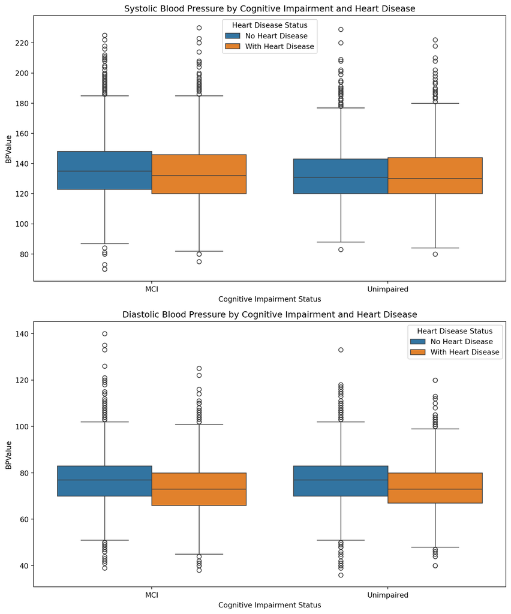

```python
import seaborn as sns
import matplotlib.pyplot as plt

df_boxplot = nacc_df.copy()
df_boxplot["SRI"] = sriScore



# Define a function to check for any heart disease
def check_cardiovascular_disease(row):
    # Initialize a list to store the status of each condition
    conditions = [row['CVAFIB'], row['CVANGIO'], row['CVBYPASS'], row['CVPACDEF'], row['CVCHF'], row['CVANGINA'], row['CVHVALVE'], row['CVOTHR']]

    # Check for 'Recent/Active'
    if any(condition in ['Recent/Active'] for condition in conditions):
        return 'With Heart Disease'

    # Check for 'Unknown' conditions due to NaN values
    if any(pd.isna(condition) for condition in conditions):
        return 'Unknown'  # Return 'Unknown' if any heart condition column has NaN


    return 'No Heart Disease'


# Apply the function to create a new column
df_boxplot['CardiovascularDiseaseStatus'] = df_boxplot.apply(check_cardiovascular_disease, axis=1)


# Melting the DataFrame to long format
long_data = df_boxplot.melt(id_vars=['CardiovascularDiseaseStatus', 'SRI'], value_vars=['BPSYS', 'BPDIAS'],
                      var_name='BPType', value_name='BPValue')

# Filter out 'Unknown' Heart Disease Status
filtered_data = long_data[long_data['CardiovascularDiseaseStatus'] != 'Unknown']

# Create separate plots for Systolic and Diastolic Blood Pressure
fig, axes = plt.subplots(2, 1, figsize=(10, 12), sharex=False)  # Changed sharex to False

# Systolic Blood Pressure plot
sns.boxplot(ax=axes[0], data=filtered_data[filtered_data['BPType'] == 'BPSYS'],
            x='SRI', y='BPValue', hue='CardiovascularDiseaseStatus', dodge=True)
axes[0].set_title('Systolic Blood Pressure by Cognitive Impairment and Heart Disease')
axes[0].set_xlabel('Cognitive Impairment Status')  # Explicitly set x-label
axes[0].legend(title='Heart Disease Status')

# Diastolic Blood Pressure plot
sns.boxplot(ax=axes[1], data=filtered_data[filtered_data['BPType'] == 'BPDIAS'],
            x='SRI', y='BPValue', hue='CardiovascularDiseaseStatus', dodge=True)
axes[1].set_title('Diastolic Blood Pressure by Cognitive Impairment and Heart Disease')
axes[1].set_xlabel('Cognitive Impairment Status')  # Explicitly set x-label
axes[1].legend(title='Heart Disease Status')

# Improve layout and visibility
plt.tight_layout()
plt.show()
```

```python
df_cvd_analysis = nacc_df[["CVAFIB", "CVANGIO", "CVBYPASS", "CVPACDEF", "CVCHF", "CVANGINA", "CVHVALVE", "CVOTHR"]].copy()

# Rename columns for readability
df_cvd_analysis.rename(columns={
    'CVAFIB': 'Atrial Fibrillation',
    'CVANGIO': 'Vascular Procedure',
    'CVBYPASS': 'Cardiac Bypass',
    'CVPACDEF': 'Pacemaker/Defibrillator',
    'CVCHF': 'Heart Failure',
    'CVANGINA': 'Angina',
    'CVHVALVE': 'Heart Valve Repair',
    'CVOTHR': 'Other Cardiovascular Disease',
}, inplace=True)

# List of columns to tabulate
columns_to_tabulate = df_cvd_analysis.columns

# Initialize an empty dataframe for the results
cvd_table = pd.DataFrame(columns=['Recent/Active', 'Absent', 'Remote/Inactive', 'Unknown'])

# Calculate percentages for each column and add to the result dataframe
for col in columns_to_tabulate:
    percentages = calculate_percentages(df_cvd_analysis[col])
    cvd_table.loc[col] = [
        round(percentages.get('Recent/Active', 0), 2),
        round(percentages.get('Absent', 0), 2),
        round(percentages.get('Remote/Inactive', 0), 2),
        round(percentages.get(float('nan'), 0), 2)  # Handling NaN values as 'Unknown'
    ]

# Display the result
cvd_table
```

|  | Recent/Active | Absent | Remote/Inactive | Unknown |
| --- | --- | --- | --- | --- |
| Atrial Fibrillation | 4.78 | 92.80 | 1.76 | 0.66 |
| Vascular Procedure | 2.24 | 93.59 | 3.90 | 0.27 |
| Cardiac Bypass | 0.84 | 95.73 | 3.17 | 0.26 |
| Pacemaker/Defibrillator | 0.39 | 26.37 | 0.06 | 73.18 |
| Heart Failure | 1.61 | 97.38 | 0.65 | 0.37 |
| Angina | 0.35 | 25.97 | 0.50 | 73.18 |
| Heart Valve Repair | 0.15 | 26.51 | 0.15 | 73.18 |
| Other Cardiovascular Disease | 6.58 | 89.41 | 3.33 | 0.68 |

# Creating dichotomous variables for CVD

```python
def has_cvd(row):
    # Initialize a list to store the status of each condition
    conditions = [row['CVAFIB'], row['CVANGIO'], row['CVBYPASS'], row['CVPACDEF'], row['CVCHF'], row['CVANGINA'], row['CVHVALVE'], row['CVOTHR'], row['CBSTROKE'], row['HYPERTEN']]

    # Check for 'Recent/Active'
    if any(condition in ['Recent/Active'] for condition in conditions):
        return "Yes"

    # Check for 'Unknown' conditions due to NaN values
    if any(pd.isna(condition) for condition in conditions):
        return 'Unknown'  # Return 'Unknown' if any heart condition column has NaN

    return "No"

# Apply the function to create a new column
HasCardiovascularDisease = nacc_df.apply(has_cvd, axis=1)
```

# Creating dichotomous variables for sleep

```python
def has_sleep_issue(row):
    # Initialize a list to store the status of each condition
    conditions = [row['APNEA'], row['INSOMN']]

    # Check for "Yes"
    if any(condition in ['Yes'] for condition in conditions):
        return "Yes"

    # Check for 'Unknown' conditions due to NaN values
    if any(pd.isna(condition) for condition in conditions):
        return 'Unknown'  # Return 'Unknown' if any heart condition column has NaN

    return "No"

# Apply the function to create a new column
HasSleepIssue = nacc_df.apply(has_sleep_issue, axis=1)
```

```python
df_full_cvd_analysis = nacc_df.copy()

# Here we are using the calculated SRI score derived from the combination of the cognitive scores from MoCA and MMSE
df_full_cvd_analysis["SRI"] = sriScore
df_full_cvd_analysis["HasCardiovascularDisease"] = HasCardiovascularDisease
df_full_cvd_analysis["HasSleepIssue"] = HasSleepIssue


# Create labels for the variables for better readability in the table
df_full_cvd_analysis.rename(columns={
    'NACCAGE': 'Age',
    'SEX': 'Sex',
    'RACE': 'Race',
    'EDUC': 'Education (years)',
    'NACCBMI': 'BMI',
    'BPSYS': 'Systolic Blood Pressure',
    'BPDIAS': 'Diastolic Blood Pressure',
    'SRI': 'Cognitive Impairment',
    'HasCardiovascularDisease': 'Cardiovascular Disease',
    'HasSleepIssue': 'Has Sleep Issue',
}, inplace=True)


# Define the desired order for the categorical variables
cat_order1 = ["Yes", "No", "Unknown"]

# Reorder the categories for 'Sleep Apnea', 'REM Disorder', 'Insomnia', and 'Other Sleep Issues'
df_full_cvd_analysis['Cardiovascular Disease'] = pd.Categorical(df_full_cvd_analysis['Cardiovascular Disease'], categories=cat_order1, ordered=True)
df_full_cvd_analysis['Has Sleep Issue'] = pd.Categorical(df_full_cvd_analysis['Has Sleep Issue'], categories=cat_order1, ordered=True)


# Define the columns to be included in the TableOne
columns = ['Age', 'Sex', 'Race', 'Education (years)', 'BMI', 'Systolic Blood Pressure', 'Diastolic Blood Pressure', 'Cardiovascular Disease', 'Has Sleep Issue']
categorical = ['Sex', 'Race', 'Cardiovascular Disease', 'Has Sleep Issue']
groupby = 'Cognitive Impairment'

# Create the demographics table
table = TableOne(df_full_cvd_analysis, columns=columns, categorical=categorical, groupby=groupby, pval=True)

# Print the table
table.tabulate(tablefmt="html")
```

|  |  | Missing | Overall | MCI | Unimpaired | P-Value |
| --- | --- | --- | --- | --- | --- | --- |
| n |  |  | 44908 | 26500 | 15997 |  |
| Age, mean (SD) |  | 0 | 71.5 (10.4) | 72.8 (10.1) | 69.3 (10.4) | <0.001 |
| Sex, n (%) | Female |  | 25647 (57.1) | 14171 (53.5) | 10147 (63.4) | <0.001 |
|  | Male |  | 19261 (42.9) | 12329 (46.5) | 5850 (36.6) |  |
| Race, n (%) | American Indian or Alaska Native |  | 395 (0.9) | 300 (1.1) | 86 (0.5) | <0.001 |
|  | Asian |  | 1191 (2.7) | 608 (2.3) | 337 (2.1) |  |
|  | Black or African American |  | 6302 (14.0) | 4291 (16.2) | 1794 (11.2) |  |
|  | Native Hawaiian or Other Pacific Islander |  | 47 (0.1) | 32 (0.1) | 11 (0.1) |  |
|  | None |  | 299 (0.7) | 211 (0.8) | 49 (0.3) |  |
|  | Other |  | 711 (1.6) | 566 (2.1) | 108 (0.7) |  |
|  | White |  | 35963 (80.1) | 20492 (77.3) | 13612 (85.1) |  |
| Education (years), mean (SD) |  | 356 | 15.1 (3.5) | 14.5 (3.6) | 16.2 (2.8) | <0.001 |
| BMI, mean (SD) |  | 5025 | 27.1 (5.3) | 27.1 (5.3) | 27.3 (5.4) | <0.001 |
| Systolic Blood Pressure, mean (SD) |  | 4176 | 134.2 (18.8) | 135.4 (19.2) | 132.3 (18.0) | <0.001 |
| Diastolic Blood Pressure, mean (SD) |  | 4188 | 75.4 (10.6) | 75.5 (10.7) | 75.3 (10.4) | 0.137 |
| Cardiovascular Disease, n (%) | Yes |  | 23646 (52.7) | 14749 (55.7) | 7782 (48.6) | <0.001 |
|  | No |  | 6067 (13.5) | 3288 (12.4) | 2450 (15.3) |  |
|  | Unknown |  | 15195 (33.8) | 8463 (31.9) | 5765 (36.0) |  |
| Has Sleep Issue, n (%) | Yes |  | 3754 (8.4) | 2233 (8.4) | 1342 (8.4) | 0.200 |
|  | No |  | 7952 (17.7) | 4644 (17.5) | 2913 (18.2) |  |
|  | Unknown |  | 33202 (73.9) | 19623 (74.0) | 11742 (73.4) |  |

```python
from statsmodels.stats.contingency_tables import mcnemar
from IPython.display import display



df_stat_analysis = nacc_df.copy()

# Here we are using the calculated SRI score derived from the combination of the cognitive scores from MoCA and MMSE
df_stat_analysis["SRI"] = sriScore
df_stat_analysis["HasCardiovascularDisease"] = HasCardiovascularDisease
df_stat_analysis["HasSleepIssue"] = HasSleepIssue

# Filter out rows where any of the columns has 'Unknown' or NA

df_stat_analysis = df_stat_analysis[(df_stat_analysis['SRI'] != 'Unknown') & (df_stat_analysis['SRI'].notna()) &
                        (df_stat_analysis['HasCardiovascularDisease'] != 'Unknown') & (df_stat_analysis['HasCardiovascularDisease'].notna()) &
                        (df_stat_analysis['HasSleepIssue'] != 'Unknown') & (df_stat_analysis['HasSleepIssue'].notna())]


# Create a new column 'impairment2' based on conditions in the 'impairment' column
df_stat_analysis['impairment2'] = df_stat_analysis['SRI'].apply(lambda x: 'Yes' if x == 'MCI' else 'No')
impairment2 = df_stat_analysis['impairment2']


# List of columns that need reordering
columns_to_reorder = ['impairment2', 'HasCardiovascularDisease', 'HasSleepIssue']

# Convert each specified column to categorical with the desired order
for column in columns_to_reorder:
    df_stat_analysis[column] = pd.Categorical(df_stat_analysis[column], categories=["Yes", "No"], ordered=True)



# Cognitive status by CVD
impair_cvd = pd.crosstab(index=df_stat_analysis['impairment2'], columns=df_stat_analysis['HasCardiovascularDisease'], rownames=['Cognitive Status'], colnames=['CVD'])

display(impair_cvd)
display(impair_cvd / impair_cvd.sum().sum().round(2))

# Cognitive status by Sleep Problems
impair_sleep = pd.crosstab(index=df_stat_analysis['impairment2'], columns=df_stat_analysis['HasSleepIssue'], rownames=['Cognitive Status'], colnames=['Sleep Problems'])

display(impair_sleep)
display(impair_sleep / impair_sleep.sum().sum().round(2))

# CVD by Sleep Problems
cvd_sleep = pd.crosstab(index=df_stat_analysis['HasCardiovascularDisease'], columns=df_stat_analysis['HasSleepIssue'], rownames=['CVD'], colnames=['Sleep Problems'])

display(cvd_sleep)
display(cvd_sleep / cvd_sleep.sum().sum().round(2))
```

| CVD Cognitive Status | Yes | No |
| --- | --- | --- |
| Yes | 3612 | 3216 |
| No | 1805 | 2415 |

| CVD Cognitive Status | Yes | No |
| --- | --- | --- |
| Yes | 0.326937 | 0.291093 |
| No | 0.163378 | 0.218592 |

| Sleep Problems Cognitive Status | Yes | No |
| --- | --- | --- |
| Yes | 2218 | 4610 |
| No | 1327 | 2893 |

| Sleep Problems Cognitive Status | Yes | No |
| --- | --- | --- |
| Yes | 0.200760 | 0.417270 |
| No | 0.120112 | 0.261857 |

| Sleep Problems CVD | Yes | No |
| --- | --- | --- |
| Yes | 2021 | 3396 |
| No | 1524 | 4107 |

| Sleep Problems CVD | Yes | No |
| --- | --- | --- |
| Yes | 0.182929 | 0.307386 |
| No | 0.137944 | 0.371741 |

```python
# Conducting McNemar's Test
# McNemar's test requires a 2x2 contingency table as input

# Cognitive status by CVD
result_impair_cvd = mcnemar(impair_cvd, exact=False)

# Cognitive status by Sleep Problems
result_impair_sleep = mcnemar(impair_sleep, exact=False)

# CVD by Sleep Problems
result_cvd_sleep = mcnemar(cvd_sleep, exact=False)

# Prepare the data for the table
results_data = {
    'Test Comparison': [
        'Cognitive status by CVD',
        'Cognitive status by Sleep Problems',
        'CVD by Sleep Problems'
    ],
    'Statistic': [
        result_impair_cvd.statistic,
        result_impair_sleep.statistic,
        result_cvd_sleep.statistic
    ],
    'p-value': [
        f"{result_impair_cvd.pvalue:.3e}",  # Format the p-value for readability
        f"{result_impair_sleep.pvalue:.3e}",
        f"{result_cvd_sleep.pvalue:.3e}"
    ]
}

# Create a DataFrame from the data
results_df = pd.DataFrame(results_data)

# Display the DataFrame
results_df
```

|  | Test Comparison | Statistic | p-value |
| --- | --- | --- | --- |
| 0 | Cognitive status by CVD | 395.956981 | 4.179e-88 |
| 1 | Cognitive status by Sleep Problems | 1814.304194 | 0.000e+00 |
| 2 | CVD by Sleep Problems | 711.512398 | 9.382e-157 |

```python
import statsmodels.api as sm
import statsmodels.formula.api as smf

'''
df_stat_analysis2 = nacc_df.copy()

# Here we are using the calculated SRI score derived from the combination of the cognitive scores from MoCA and MMSE
df_stat_analysis2["SRI"] = impairment2
df_stat_analysis2["HasCardiovascularDisease"] = HasCardiovascularDisease
df_stat_analysis2["HasSleepIssue"] = HasSleepIssue



df_stat_analysis2 = df_stat_analysis2[(df_stat_analysis2['SRI'] != 'Unknown') & (df_stat_analysis2['SRI'].notna()) &
                        (df_stat_analysis2['HasCardiovascularDisease'] != 'Unknown') & (df_stat_analysis2['HasCardiovascularDisease'].notna()) &
                        (df_stat_analysis2['HasSleepIssue'] != 'Unknown') & (df_stat_analysis2['HasSleepIssue'].notna())]






print(df_stat_analysis2["HasCardiovascularDisease"].unique())

#df_stat_analysis2['SRI'] = df_stat_analysis2['SRI'].map({'No': 0, 'Yes': 1})
df_stat_analysis2['SRI'] = df_stat_analysis2['SRI'].map({'Yes': 0, 'No': 1})


# df_stat_analysis2['HasCardiovascularDisease'] = df_stat_analysis2['HasCardiovascularDisease'].map({'No': 0, 'Yes': 1})
# df_stat_analysis2['HasSleepIssue'] = df_stat_analysis2['HasSleepIssue'].map({'No': 0, 'Yes': 1})


# Model 1: Simple logistic regression of impairment on sleep_problems
model1 = smf.logit("SRI ~ C(HasSleepIssue)", data=df_stat_analysis2).fit()
print(model1.summary())


# Model 2: Interaction between cvd_all and sleep_problems
model2 = smf.logit("SRI ~ C(HasCardiovascularDisease) * C(HasSleepIssue)", data=df_stat_analysis2).fit()
print(model2.summary())

df_stat_analysis2['HasCardiovascularDisease'] = df_stat_analysis2['HasCardiovascularDisease'].map({'No': 0, 'Yes': 1})

# Model 3: Logistic regression of cvd_all on sleep_problems
model3 = smf.logit("HasCardiovascularDisease ~ C(HasSleepIssue)", data=df_stat_analysis2).fit()
print(model3.summary())

# Model 4: Adding cvd_all as a covariate
model4 = smf.logit("SRI ~ C(HasCardiovascularDisease) + C(HasSleepIssue)", data=df_stat_analysis2).fit()
print(model4.summary())

# Model 5: Same as model 1, usually for comparison, can be skipped in actual code as it's a duplicate
model5 = model1  # Reusing the first model as it's the same

# Model 6: Adding AGE and education (assuming 'PTEDUCAT' stands for education)
model6 = smf.logit("SRI ~ C(HasSleepIssue) + NACCAGE + EDUC", data=df_stat_analysis2).fit()
print(model6.summary())

'''
```

[output not shown]

# Adjusted/NEWEST

```python
import statsmodels.api as sm
import statsmodels.formula.api as smf


df_stat_analysis2 = nacc_df.copy()

# Here we are using the calculated SRI score derived from the combination of the cognitive scores from MoCA and MMSE
df_stat_analysis2["SRI"] = impairment2
df_stat_analysis2["HasCardiovascularDisease"] = HasCardiovascularDisease
df_stat_analysis2["HasSleepIssue"] = HasSleepIssue



df_stat_analysis2 = df_stat_analysis2[(df_stat_analysis2['SRI'] != 'Unknown') & (df_stat_analysis2['SRI'].notna()) &
                        (df_stat_analysis2['HasCardiovascularDisease'] != 'Unknown') & (df_stat_analysis2['HasCardiovascularDisease'].notna()) &
                        (df_stat_analysis2['HasSleepIssue'] != 'Unknown') & (df_stat_analysis2['HasSleepIssue'].notna())]






print(df_stat_analysis2["HasCardiovascularDisease"].unique())

#df_stat_analysis2['SRI'] = df_stat_analysis2['SRI'].map({'No': 0, 'Yes': 1})
df_stat_analysis2['SRI'] = df_stat_analysis2['SRI'].map({'Yes': 0, 'No': 1})

'''
df_stat_analysis2['HasCardiovascularDisease'] = df_stat_analysis2['HasCardiovascularDisease'].map({'No': 0, 'Yes': 1})
df_stat_analysis2['HasSleepIssue'] = df_stat_analysis2['HasSleepIssue'].map({'No': 0, 'Yes': 1})
'''

# Model 1: Simple logistic regression of impairment on sleep_problems
model1 = smf.logit("SRI ~ C(HasSleepIssue)", data=df_stat_analysis2).fit()
print(model1.summary())

df_stat_analysis2['HasCardiovascularDisease'] = df_stat_analysis2['HasCardiovascularDisease'].map({'No': 0, 'Yes': 1})


# Model 4: Adding cvd_all as a covariate
model4 = smf.logit("SRI ~ C(HasCardiovascularDisease)", data=df_stat_analysis2).fit()
print(model4.summary())


# Model 6: Adding AGE and education (assuming 'PTEDUCAT' stands for education)
model6 = smf.logit("SRI ~ NACCAGE + EDUC", data=df_stat_analysis2).fit()
print(model6.summary())
```

```
['Yes' 'No']
Optimization terminated successfully.
         Current function value: 0.664962
         Iterations 4
                           Logit Regression Results
==============================================================================
Dep. Variable:                    SRI   No. Observations:                11048
Model:                          Logit   Df Residuals:                    11046
Method:                           MLE   Df Model:                            1
Date:                Wed, 17 Jul 2024   Pseudo R-squ.:               8.795e-05
Time:                        12:01:23   Log-Likelihood:                -7346.5
converged:                       True   LL-Null:                       -7347.1
Covariance Type:            nonrobust   LLR p-value:                    0.2556
===========================================================================================
                              coef    std err          z      P>|z|      [0.025      0.975]
-------------------------------------------------------------------------------------------
Intercept                  -0.4659      0.024    -19.644      0.000      -0.512      -0.419
C(HasSleepIssue)[T.Yes]    -0.0478      0.042     -1.136      0.256      -0.130       0.035
===========================================================================================
Optimization terminated successfully.
         Current function value: 0.660163
         Iterations 4
                           Logit Regression Results
==============================================================================
Dep. Variable:                    SRI   No. Observations:                11048
Model:                          Logit   Df Residuals:                    11046
Method:                           MLE   Df Model:                            1
Date:                Wed, 17 Jul 2024   Pseudo R-squ.:                0.007303
Time:                        12:01:23   Log-Likelihood:                -7293.5
converged:                       True   LL-Null:                       -7347.1
Covariance Type:            nonrobust   LLR p-value:                 3.790e-25
====================================================================================================
                                       coef    std err          z      P>|z|      [0.025      0.975]
----------------------------------------------------------------------------------------------------
Intercept                           -0.2864      0.027    -10.638      0.000      -0.339      -0.234
C(HasCardiovascularDisease)[T.1]    -0.4073      0.039    -10.325      0.000      -0.485      -0.330
====================================================================================================
Optimization terminated successfully.
         Current function value: 0.623308
         Iterations 5
                           Logit Regression Results
==============================================================================
Dep. Variable:                    SRI   No. Observations:                11046
Model:                          Logit   Df Residuals:                    11043
Method:                           MLE   Df Model:                            2
Date:                Wed, 17 Jul 2024   Pseudo R-squ.:                 0.06277
Time:                        12:01:23   Log-Likelihood:                -6885.1
converged:                       True   LL-Null:                       -7346.2
Covariance Type:            nonrobust   LLR p-value:                5.482e-201
==============================================================================
                 coef    std err          z      P>|z|      [0.025      0.975]
------------------------------------------------------------------------------
Intercept     -0.6117      0.185     -3.315      0.001      -0.973      -0.250
NACCAGE       -0.0394      0.002    -18.415      0.000      -0.044      -0.035
EDUC           0.1770      0.008     22.821      0.000       0.162       0.192
==============================================================================
```

```python
from stargazer.stargazer import Stargazer
'''

# Create a Stargazer object
stargazer = Stargazer([model1, model2, model3, model4, model6])


# Configure Stargazer (optional, customize as needed)
stargazer.custom_columns(['Model 1', 'Model 2', 'Model 3', 'Model 4', 'Model 6'], [1, 1, 1, 1, 1])


# Render HTML (if using Jupyter) or export to text/latex as needed
html_code = stargazer.render_html()

# Optionally save the HTML to a file
with open("model_summaries.html", "w") as file:
    file.write(html_code)

html_code
'''
```

[output not shown]

# Adjusted/NEWEST

```python
from stargazer.stargazer import Stargazer

# Create a Stargazer object
stargazer = Stargazer([model1, model4, model6])


# Configure Stargazer (optional, customize as needed)
stargazer.custom_columns(['Model 1', 'Model 2', 'Model 3'], [1, 1, 1])


# Render HTML (if using Jupyter) or export to text/latex as needed
html_code = stargazer.render_html()

# Optionally save the HTML to a file
with open("model_summaries.html", "w") as file:
    file.write(html_code)

html_code
```

|  | *Dependent variable: SRI* |  |  |
| --- | --- | --- | --- |
|  | Model 1 | Model 2 | Model 3 |
|  | (1) | (2) | (3) |
| C(HasCardiovascularDisease)[T.1] |  | -0.407*** |  |
|  |  | (0.039) |  |
| C(HasSleepIssue)[T.Yes] | -0.048 |  |  |
|  | (0.042) |  |  |
| EDUC |  |  | 0.177*** |
|  |  |  | (0.008) |
| Intercept | -0.466*** | -0.286*** | -0.612*** |
|  | (0.024) | (0.027) | (0.185) |
| NACCAGE |  |  | -0.039*** |
|  |  |  | (0.002) |
| Observations | 11048 | 11048 | 11046 |
| Pseudo R<sup>2</sup> | 0.000 | 0.007 | 0.063 |
| Note: | *p<0.1; **p<0.05;*** p<0.01 |  |  |